# State variables: monthly environmental state of 14 sanctuaries

- Show All Code
- Hide All Code
- View Source

Re-derived from the Copernicus NetCDFs with depth masks and small-sanctuary buffers

This notebook rebuilds the monthly sanctuary averages in copernicus from the NetCDF files already on disk and changes two things:

- **Bottom temperature (`sbt`) uses shelf cells only**, i.e. model cells with seafloor depth <= 200 m (GLORYS12V1 static `deptho`). The old polygon mean mixed shelf and abyssal water.
- **Chlorophyll (`chl`) and primary production (`pp`) use optically deep pixels only** (ETOPO 2022 depth >= 30 m, averaged onto the 4 km grid), summarised as a spatial geometric mean.

Monitor, Gray’s Reef and Flower Garden Banks cover only 1-4 model cells, so for every variable their polygon is buffered by 10 km. The old definitions are kept as `sbt_all` and `chl_all` and must reproduce `data/copernicus.csv`. Precipitation is copied from `data/erddap.csv`.

Papahānaumokuākea (`PNMS`, designated 2025) is not in the old extracts. Its physics, ocean colour, bathymetry and precipitation are downloaded here for the two polygon parts on either side of the antimeridian (one box each). Because the polygon spans 12.5 degrees of latitude, every PNMS mean is weighted by cos(latitude).

```r
librarian::shelf(
  dplyr, ggplot2, glue, here, knitr, patchwork, purrr, readr, sf, stringr,
  terra, tibble, tidyr,
  quiet = T)
options(readr.show_col_types = F, timeout = 3600)

# paths ----
dir_cm         <- here("data/copernicus")
dir_state      <- here("data/state")
dir_bathy      <- here("data/state/bathy")
dir_pnms       <- here("data/raw/pnms")                   # git-ignored downloads for PNMS
dir_fig        <- here("figures/state")
ply_geo        <- here("data/sanctuaries.geojson")
pnms_geo       <- file.path(dir_state, "pnms.geojson")
copernicus_csv <- here("data/copernicus.csv")
erddap_csv     <- here("data/erddap.csv")
phy_depth_csv  <- file.path(dir_bathy, "phy_depth.csv")   # glorys deptho on each physics grid
oc_depth_csv   <- file.path(dir_bathy, "oc_depth.csv")    # etopo 2022 averaged onto each 4 km grid
chnms_geo      <- file.path(dir_state, "chnms_designated.geojson")
pnms_log_csv   <- file.path(dir_state, "pnms_downloads.csv")
monthly_csv    <- file.path(dir_state, "state_monthly.csv")
cells_csv      <- file.path(dir_state, "state_cells.csv")
compare_csv    <- file.path(dir_state, "state_compare.csv")
cmt_cli        <- path.expand("~/.virtualenvs/CopernicusMarine/bin/copernicusmarine")
dir.create(dir_bathy, showWarnings = F, recursive = T)
dir.create(dir_pnms,  showWarnings = F, recursive = T)
dir.create(dir_fig,   showWarnings = F, recursive = T)

# constants ----
NMS_ORD <- c(
  "OCNMS", "GFNMS", "CBNMS", "MBNMS", "CPNMS", "CINMS", "PNMS", "HIHWNMS", "NMSAS",
  "FGBNMS", "FKNMS", "GRNMS", "MNMS", "SBNMS")
NMS_CM    <- setdiff(NMS_ORD, "PNMS")       # the 13 in data/copernicus/ and data/copernicus.csv
NMS_COS   <- "PNMS"                         # means weighted by cos(latitude)
NMS_BUF   <- c("MNMS", "GRNMS", "FGBNMS")   # tiny sanctuaries: polygon + 10 km
BUF_M     <- 10000
SHELF_M   <- 200                            # sbt: model depth <= 200 m
SHELF_MIN <- 3                              # fewer shelf cells -> sbt NA
OPT_M     <- 30                             # chl, pp: depth >= 30 m is optically deep
OPT_MIN   <- 10                             # fewer deep pixels -> use all pixels
TOL       <- 1e-4                           # agreement with data/copernicus.csv
PNMS_PAD  <- 0.1                            # deg padding of each PNMS part box
DS <- c(
  phy = "cmems_mod_glo_phy_my_0.083deg_P1M-m",
  chl = "cmems_obs-oc_glo_bgc-plankton_my_l4-multi-4km_P1M",
  pp  = "cmems_obs-oc_glo_bgc-pp_my_l4-multi-4km_P1M")
DS_STATIC <- "cmems_mod_glo_phy_my_0.083deg_static"
PNMS_VER  <- c(phy = "202311", chl = "202411", pp = "202311")   # versions when the old extracts were pulled
VARS_OUT  <- c("sst", "sbt", "sss", "mld", "chl", "pp", "precip", "sbt_all", "chl_all")
ETOPO_URL <- "https://coastwatch.pfeg.noaa.gov/erddap/griddap/ETOPO_2022_v1_15s"
IMERG_URL <- "https://erddap.marine.usf.edu/erddap/griddap/IMERG_monthly_global_precip"
CHNMS_URL <- "https://sanctuaries.noaa.gov/media/gis/chnms_py.zip"

# plot theme (from trajectory_checks.qmd) ----
PAL <- list(
  surface = "#fcfcfb", ink = "#0b0b0b", ink2 = "#52514e", muted = "#898781",
  grid    = "#e1e0d9", axis = "#c3c2b7", blue = "#2a78d6", orange = "#eb6834")

theme_chk <- function(base_size = 10) {
  theme_minimal(base_size = base_size) +
    theme(
      plot.background    = element_rect(fill = PAL$surface, color = NA),
      panel.background   = element_rect(fill = PAL$surface, color = NA),
      panel.grid.major   = element_line(color = PAL$grid, linewidth = 0.25),
      panel.grid.minor   = element_blank(),
      axis.text          = element_text(color = PAL$muted),
      axis.title         = element_text(color = PAL$ink2),
      plot.title         = element_text(color = PAL$ink, face = "bold", size = rel(1.1)),
      plot.subtitle      = element_text(color = PAL$ink2),
      plot.caption       = element_text(color = PAL$muted, hjust = 0),
      plot.title.position = "plot",
      strip.text         = element_text(color = PAL$ink, face = "bold", hjust = 0),
      legend.position    = "top",
      legend.justification = "left",
      legend.title       = element_text(color = PAL$ink2),
      legend.text        = element_text(color = PAL$ink2))
}
save_fig <- function(p, name, width = 9, height = 5) {
  ggsave(file.path(dir_fig, name), p, width = width, height = height, dpi = 200, bg = PAL$surface)
  p
}
```

```r
# netcdf files per sanctuary and dataset ('my' only; 'myint' duplicates 'my') ----
nc_files <- function(nms, ds) {
  f <- list.files(file.path(dir_cm, nms), full.names = T)
  f[startsWith(basename(f), paste0(DS[[ds]], "_multi-vars"))]
}

# last month the 13 sanctuaries have, per dataset (PNMS is downloaded to the same end) ----
last_month <- function(ds) {
  var <- c(phy = "bottomT", chl = "CHL", pp = "PP")[[ds]]
  map(NMS_CM, \(n) map(nc_files(n, ds), \(f) as.Date(time(rast(f, subds = var))))) |>
    unlist() |> as.Date() |> max()
}
END <- map(names(DS), last_month) |> set_names(names(DS))
stopifnot(END$chl == END$pp)

# polygons ----
ply_pnms <- read_sf(pnms_geo) |> select(sanctuary, nms)
stopifnot(nrow(ply_pnms) == 1, ply_pnms$nms == "PNMS")
ply_all <- read_sf(ply_geo) |>
  filter(nms %in% NMS_CM) |>
  select(sanctuary, nms) |>
  bind_rows(ply_pnms)
stopifnot(setequal(ply_all$nms, NMS_ORD))

# polygon used for the masked variables: buffered for the tiny sanctuaries
ply_use <- ply_all
i_buf   <- which(ply_use$nms %in% NMS_BUF)
st_geometry(ply_use)[i_buf] <- st_cast(st_buffer(st_geometry(ply_use)[i_buf], BUF_M), "MULTIPOLYGON")
ply_use$area_km2 <- as.numeric(st_area(ply_use)) / 1e6
ply_all$area_km2 <- as.numeric(st_area(ply_all)) / 1e6

# pnms: one box per polygon part, padded, never across the antimeridian ----
pnms_box <- map(st_cast(st_geometry(ply_pnms), "POLYGON"), \(g) {
  b <- st_bbox(g)
  c(xmin = max(-180, b[["xmin"]] - PNMS_PAD), xmax = min(180, b[["xmax"]] + PNMS_PAD),
    ymin = b[["ymin"]] - PNMS_PAD,            ymax = b[["ymax"]] + PNMS_PAD)
})
names(pnms_box) <- if_else(map_dbl(pnms_box, "xmin") > 0, "PNMS-east", "PNMS-west")
stopifnot(setequal(names(pnms_box), c("PNMS-east", "PNMS-west")))

# grids: one per sanctuary, two for pnms ----
d_grid <- bind_rows(
  tibble(grid = NMS_CM, nms = NMS_CM),
  tibble(grid = names(pnms_box), nms = "PNMS"))
grid_files <- function(grid, ds) {
  if (startsWith(grid, "PNMS")) file.path(dir_pnms, glue("{grid}_{ds}.nc")) else nc_files(grid, ds)
}
```

### Papahānaumokuākea downloads

Physics, chlorophyll and primary production from Copernicus Marine (toolbox CLI), pinned to the product versions of the old extracts where still served; IMERG precipitation from the USF ERDDAP. Files are cached under `data/raw/pnms/` (git-ignored); the log of what was fetched is `data/state/pnms_downloads.csv`.

```r
cm_get <- function(grid, ds, vars, t0 = NULL, t1 = NULL, depth = F) {
  nc    <- file.path(dir_pnms, glue("{grid}_{ds}.nc"))
  b     <- pnms_box[[grid]]
  ds_id <- if (ds == "deptho") DS_STATIC else DS[[ds]]
  ver   <- if (ds %in% names(PNMS_VER)) PNMS_VER[[ds]] else NA_character_
  args  <- c(
    "subset", "--dataset-id", ds_id, as.vector(rbind("--variable", vars)),
    "--minimum-longitude", b[["xmin"]], "--maximum-longitude", b[["xmax"]],
    "--minimum-latitude",  b[["ymin"]], "--maximum-latitude",  b[["ymax"]],
    if (!is.null(t0)) c("--start-datetime", glue("{t0}T00:00:00"), "--end-datetime", glue("{t1}T00:00:00")),
    if (depth) c("--minimum-depth", 0, "--maximum-depth", 0.5),
    "--output-directory", dir_pnms, "--output-filename", basename(nc), "--disable-progress-bar")
  run <- function(a) {
    secs <- system.time(
      out <- suppressWarnings(system2(cmt_cli, a, stdout = T, stderr = T)))[["elapsed"]]
    list(out = out, ok = is.null(attr(out, "status")) && file.exists(nc), secs = secs)
  }
  r      <- if (is.na(ver)) run(args) else run(c(args, "--dataset-version", ver))
  pinned <- !is.na(ver) && r$ok
  if (!r$ok) r <- run(args)                        # pinned version no longer served: use the current one
  stopifnot(r$ok)
  v_used <- na.omit(str_match(r$out, 'Selected dataset version: "([0-9]+)"')[, 2])[1]
  tibble(
    grid, ds, dataset_id = ds_id, version_requested = ver, version_used = v_used, pinned,
    file = basename(nc), mb = round(file.size(nc) / 1e6, 1), seconds = round(r$secs))
}

im_get <- function(grid) {
  b  <- pnms_box[[grid]]
  t0 <- seq(as.Date("1998-01-01"), as.Date("2025-09-01"), by = "7 years")
  t1 <- c(t0[-1] - 31, as.Date("2025-09-01"))
  t1 <- as.Date(format(t1, "%Y-%m-01"))
  map2(t0, t1, \(a, z) {
    nc <- file.path(dir_pnms, glue("{grid}_precip_{format(a, '%Y')}.nc"))
    q  <- glue(
      "{IMERG_URL}.nc?precipitation[({a}T00:00:00Z):1:({z}T00:00:00Z)]",
      "[({b[['ymin']]}):1:({b[['ymax']]})][({max(b[['xmin']], -179.95)}):1:({min(b[['xmax']], 179.95)})]")
    secs <- system.time(download.file(URLencode(q), nc, quiet = T, mode = "wb"))[["elapsed"]]
    tibble(
      grid, ds = "precip", dataset_id = "IMERG_monthly_global_precip", version_requested = NA_character_,
      version_used = NA_character_, pinned = NA, file = basename(nc),
      mb = round(file.size(nc) / 1e6, 1), seconds = round(secs))
  }) |> bind_rows()
}

if (!file.exists(pnms_log_csv)) {
  d_log <- map(names(pnms_box), \(g) bind_rows(
    cm_get(g, "phy", c("thetao", "so", "bottomT", "mlotst"), "1993-01-01", END$phy, depth = T),
    cm_get(g, "chl", "CHL", "1997-09-01", END$chl),
    cm_get(g, "pp",  "PP",  "1997-09-01", END$pp),
    cm_get(g, "deptho", "deptho"),
    im_get(g))) |>
    bind_rows()
  write_csv(d_log, pnms_log_csv)
}
d_log <- read_csv(pnms_log_csv)
kable(d_log, caption = "PNMS downloads (seconds = wall time of the request).")
```

PNMS downloads (seconds = wall time of the request).

| grid | ds | dataset_id | version_requested | version_used | pinned | file | mb | seconds |
| --- | --- | --- | --- | --- | --- | --- | --- | --- |
| PNMS-west | phy | cmems_mod_glo_phy_my_0.083deg_P1M-m | 202311 | 202311 | TRUE | PNMS-west_phy.nc | 111.6 | 11 |
| PNMS-west | chl | cmems_obs-oc_glo_bgc-plankton_my_l4-multi-4km_P1M | 202411 | 202603 | FALSE | PNMS-west_chl.nc | 192.9 | 11 |
| PNMS-west | pp | cmems_obs-oc_glo_bgc-pp_my_l4-multi-4km_P1M | 202311 | 202603 | FALSE | PNMS-west_pp.nc | 192.9 | 12 |
| PNMS-west | deptho | cmems_mod_glo_phy_my_0.083deg_static | NA | 202311 | FALSE | PNMS-west_deptho.nc | 0.2 | 4 |
| PNMS-west | precip | IMERG_monthly_global_precip | NA | NA | NA | PNMS-west_precip_1998.nc | 16.4 | 5 |
| PNMS-west | precip | IMERG_monthly_global_precip | NA | NA | NA | PNMS-west_precip_2005.nc | 16.4 | 4 |
| PNMS-west | precip | IMERG_monthly_global_precip | NA | NA | NA | PNMS-west_precip_2012.nc | 16.4 | 5 |
| PNMS-west | precip | IMERG_monthly_global_precip | NA | NA | NA | PNMS-west_precip_2019.nc | 15.8 | 5 |
| PNMS-east | phy | cmems_mod_glo_phy_my_0.083deg_P1M-m | 202311 | 202311 | TRUE | PNMS-east_phy.nc | 6.5 | 10 |
| PNMS-east | chl | cmems_obs-oc_glo_bgc-plankton_my_l4-multi-4km_P1M | 202411 | 202603 | FALSE | PNMS-east_chl.nc | 11.2 | 6 |
| PNMS-east | pp | cmems_obs-oc_glo_bgc-pp_my_l4-multi-4km_P1M | 202311 | 202603 | FALSE | PNMS-east_pp.nc | 11.2 | 6 |
| PNMS-east | deptho | cmems_mod_glo_phy_my_0.083deg_static | NA | 202311 | FALSE | PNMS-east_deptho.nc | 0.0 | 3 |
| PNMS-east | precip | IMERG_monthly_global_precip | NA | NA | NA | PNMS-east_precip_1998.nc | 1.0 | 3 |
| PNMS-east | precip | IMERG_monthly_global_precip | NA | NA | NA | PNMS-east_precip_2005.nc | 1.0 | 3 |
| PNMS-east | precip | IMERG_monthly_global_precip | NA | NA | NA | PNMS-east_precip_2012.nc | 1.0 | 3 |
| PNMS-east | precip | IMERG_monthly_global_precip | NA | NA | NA | PNMS-east_precip_2019.nc | 1.0 | 2 |

```r
# version note for the rules ----
ver_note <- function(ds) {
  d <- d_log |> filter(.data$ds == !!ds)
  if (all(d$pinned)) return("")
  glue(
    "; product version {d$version_used[1]} (current; {d$version_requested[1]} no longer served), ",
    "not strictly comparable with the other sanctuaries")
}
PNMS_OC_NOTE <- ver_note("chl")

d_nc <- expand_grid(d_grid, ds = names(DS)) |>
  mutate(
    files   = map2(grid, ds, grid_files),
    n_files = lengths(files))
stopifnot(all(d_nc$n_files >= 1), all(file.exists(unlist(d_nc$files))))
```

### Chumash Heritage boundary

The polygon on disk for `CPNMS` is the larger “proposed action” boundary. The designated boundary is fetched from the ONMS GIS page and used for the masked variables if at least 99% of its area lies inside the area that was downloaded. `sbt_all`, `chl_all` and `precip` stay on the proposed polygon.

```r
if (!file.exists(chnms_geo)) {
  tmp_zip <- tempfile(fileext = ".zip")
  tmp_dir <- tempfile()
  download.file(CHNMS_URL, tmp_zip, quiet = T, mode = "wb")
  unzip(tmp_zip, exdir = tmp_dir)
  read_sf(list.files(tmp_dir, "CHNMS_py[.]shp$", full.names = T)) |>
    st_transform(4326) |>
    st_make_valid() |>
    transmute(sanctuary = "Chumash Heritage (designated 2024)", nms = "CPNMS") |>
    write_sf(chnms_geo)
}
ply_chnms <- read_sf(chnms_geo)

# extent of the downloaded physics and ocean-colour files for CPNMS
ext_cp <- function(ds) {
  r <- rast(d_nc$files[[which(d_nc$grid == "CPNMS" & d_nc$ds == ds)]][1], lyrs = 1)
  as.vector(ext(r))
}
bb_dl <- rbind(ext_cp("phy"), ext_cp("chl"))
bb_dl <- c(
  xmin = max(bb_dl[, "xmin"]), xmax = min(bb_dl[, "xmax"]),
  ymin = max(bb_dl[, "ymin"]), ymax = min(bb_dl[, "ymax"]))
bb_ch <- st_bbox(ply_chnms)

sf_use_s2(F)
box_dl  <- st_as_sfc(st_bbox(bb_dl, crs = 4326))
a_ch    <- as.numeric(st_area(st_transform(ply_chnms, 3310)))
a_ch_in <- as.numeric(st_area(st_intersection(st_transform(ply_chnms, 3310), st_transform(box_dl, 3310))))
sf_use_s2(T)

# use the designated boundary if at least 99% of its area lies in the downloaded box
CHNMS_MIN_IN <- 0.99
chnms_inside <- a_ch_in / a_ch >= CHNMS_MIN_IN

if (chnms_inside) {
  i <- which(ply_use$nms == "CPNMS")
  st_geometry(ply_use)[i] <- st_geometry(st_cast(ply_chnms, "MULTIPOLYGON"))
  ply_use$area_km2[i]     <- a_ch / 1e6
}
CP_NOTE <- if (chnms_inside) {
  glue(
    "designated boundary ({floor(100 * a_ch_in / a_ch)}% of its area; the easternmost ",
    "{round(100 * (1 - a_ch_in / a_ch), 1)}% lies outside the downloaded box)")
} else "proposed-action polygon"

tibble(
  boundary       = c("proposed action (data/sanctuaries.geojson)", "designated 2024 (ONMS)"),
  area_km2       = round(c(ply_all$area_km2[ply_all$nms == "CPNMS"], a_ch / 1e6)),
  east_edge      = round(c(st_bbox(ply_all |> filter(nms == "CPNMS"))["xmax"], bb_ch["xmax"]), 3),
  pct_inside_box = c(100, round(100 * a_ch_in / a_ch, 1))) |>
  kable(caption = glue(
    "Downloaded box: {round(bb_dl['xmin'], 2)} to {round(bb_dl['xmax'], 2)} E, ",
    "{round(bb_dl['ymin'], 2)} to {round(bb_dl['ymax'], 2)} N. Used for CPNMS: {CP_NOTE}."))
```

Downloaded box: -122.29 to -120.12 E, 33.71 to 35.62 N. Used for CPNMS: designated boundary (99% of its area; the easternmost 0.9% lies outside the downloaded box).

| boundary | area_km2 | east_edge | pct_inside_box |
| --- | --- | --- | --- |
| proposed action (data/sanctuaries.geojson) | 19618 | -120.227 | 100.0 |
| designated 2024 (ONMS) | 11766 | -119.933 | 99.1 |

## Bathymetry

Depths are cached per grid in two CSVs; a grid missing from a CSV is computed and appended. For the two large PNMS grids only the cells whose centres fall in the polygon are kept.

```r
# cells selected by a polygon (centre-in-polygon; 'small' fallback) ----
poly_cells <- function(r, p) {
  sort(unique(terra::extract(r, vect(p), cells = T, ID = F)$cell))
}

cell_xy <- function(r, cells) {
  tibble(cell = cells, x = round(xFromCell(r, cells), 4), y = round(yFromCell(r, cells), 4))
}

# keep all cells, or only the polygon's cells for pnms ----
depth_rows <- function(grid, r, depth_m) {
  d <- tibble(grid = grid, cell = 1:ncell(r)) |>
    mutate(x = round(xFromCell(r, cell), 4), y = round(yFromCell(r, cell), 4), depth_m = round(depth_m, 1))
  if (startsWith(grid, "PNMS")) d <- d |> filter(cell %in% poly_cells(r, ply_all |> filter(nms == "PNMS")))
  d |> select(-cell)
}

read_depth_csv <- function(f) {
  if (!file.exists(f)) return(tibble(grid = character(), x = double(), y = double(), depth_m = double()))
  read_csv(f) |> rename(any_of(c(grid = "nms")))
}
```

```r
# glorys12v1 static deptho, one small download per physics grid (cached) ----
d_phy_depth <- read_depth_csv(phy_depth_csv)
todo        <- setdiff(d_grid$grid, d_phy_depth$grid)
if (length(todo) > 0) {
  d_new <- map(todo, \(grid) {
    r  <- rast(d_nc$files[[which(d_nc$grid == grid & d_nc$ds == "phy")]][1], subds = "bottomT", lyrs = 1)
    e  <- as.vector(ext(r))
    nc <- if (startsWith(grid, "PNMS")) {
      file.path(dir_pnms, glue("{grid}_deptho.nc"))           # downloaded with the pnms box
    } else file.path(dir_bathy, glue("{grid}_deptho.nc"))
    if (!file.exists(nc)) {
      args <- c(
        "subset", "--dataset-id", DS_STATIC, "--variable", "deptho",
        "--minimum-longitude", e["xmin"], "--maximum-longitude", e["xmax"],
        "--minimum-latitude",  e["ymin"], "--maximum-latitude",  e["ymax"],
        "--output-directory", dirname(nc), "--output-filename", basename(nc),
        "--disable-progress-bar")
      res <- system2(cmt_cli, args, stdout = F, stderr = F)
      stopifnot(res == 0, file.exists(nc))
    }
    b <- rast(nc, subds = "deptho")
    stopifnot(all(dim(b)[1:2] == dim(r)[1:2]), max(abs(as.vector(ext(b)) - e)) < 1e-3)
    depth_rows(grid, b, values(b)[, 1])
  }) |> bind_rows()
  d_phy_depth <- bind_rows(d_phy_depth, d_new)
  write_csv(d_phy_depth, phy_depth_csv)
}
```

```r
# etopo 2022 (15 arc-second) from coastwatch erddap, in 2-degree latitude bands,
# averaged onto each 4 km grid (cached) ----
etopo_get <- function(grid, e) {
  y0 <- seq(e[["ymin"]], e[["ymax"]], by = 2)
  map(y0, \(a) {
    z  <- min(a + 2, e[["ymax"]])
    nc <- if (length(y0) == 1) {
      file.path(dir_bathy, glue("{grid}_etopo2022.nc"))
    } else file.path(dir_pnms, glue("{grid}_etopo2022_{round(a, 2)}.nc"))
    if (!file.exists(nc)) {
      q <- glue(
        "{ETOPO_URL}.nc?z[({a + 0.001}):1:({z - 0.001})]",
        "[({max(e[['xmin']] + 0.001, -179.9979)}):1:({min(e[['xmax']] - 0.001, 179.9979)})]")
      download.file(URLencode(q), nc, quiet = T, mode = "wb")
    }
    rast(nc)
  }) |>
    sprc() |>
    merge()
}

d_oc_depth <- read_depth_csv(oc_depth_csv)
todo       <- setdiff(d_grid$grid, d_oc_depth$grid)
if (length(todo) > 0) {
  d_new <- map(todo, \(grid) {
    r <- rast(d_nc$files[[which(d_nc$grid == grid & d_nc$ds == "chl")]][1], subds = "CHL", lyrs = 1)
    z <- etopo_get(grid, as.vector(ext(r)))
    a <- resample(z, r, method = "average")   # mean elevation of the ~100 etopo cells in each pixel
    depth_rows(grid, r, -values(a)[, 1])
  }) |> bind_rows()
  d_oc_depth <- bind_rows(d_oc_depth, d_new)
  write_csv(d_oc_depth, oc_depth_csv)
}
```

## Extraction

Cells are chosen by centre-in-polygon (terra’s default, as in `copernicus.qmd`; if no centre falls inside, the touched cells are used). Where files of one dataset overlap in time, the longest file wins. PNMS cells from both grids are pooled into one cos(latitude)-weighted mean.

```r
# read one variable from all files of a dataset into a cell x month matrix (selected cells) ----
read_var <- function(files, var, cells) {
  rs <- map(files, \(f) rast(f, subds = var))
  rs <- rs[order(-map_int(rs, nlyr))]                # longest file first
  r0 <- rs[[1]][[1]]
  walk(rs, \(r) stopifnot(
    all(dim(r)[1:2] == dim(r0)[1:2]),
    max(abs(as.vector(ext(r)) - as.vector(ext(r0)))) < 1e-3))
  dates <- c(); m <- NULL
  for (r in rs) {
    t   <- as.Date(time(r))
    stopifnot(length(t) == nlyr(r), !anyNA(t))
    new <- !t %in% dates
    if (!any(new)) next
    m     <- cbind(m, values(r)[cells, new, drop = F])
    dates <- c(dates, t[new])
  }
  dates <- as.Date(dates)
  o     <- order(dates)
  list(dates = dates[o], m = m[, o, drop = F])
}

# per-month (weighted) summary over the rows of x ----
summ <- function(x, w, dates, fun = c("mean", "gmean")) {
  fun <- match.arg(fun)
  if (fun == "gmean") {
    x[!is.na(x) & x <= 0] <- NA
    x <- log10(x)
  }
  ok  <- !is.na(x)
  n   <- colSums(ok)
  x[!ok] <- 0
  val <- colSums(x * w) / colSums(ok * w)
  if (fun == "gmean") val <- 10^val
  val[n == 0] <- NA
  tibble(date = dates, value = unname(val), n_cells = unname(as.integer(n)))
}

# one grid: cell table and matrices for the cells in either polygon ----
grid_extract <- function(grid, kind, p_use, p_all) {
  f    <- \(ds) d_nc$files[[which(d_nc$grid == grid & d_nc$ds == ds)]]
  vars <- if (kind == "phy") {
    list(sst = c("phy", "thetao"), sss = c("phy", "so"), mld = c("phy", "mlotst"), sbt = c("phy", "bottomT"))
  } else list(chl = c("chl", "CHL"), pp = c("pp", "PP"))
  r0    <- rast(f(vars[[1]][1])[1], subds = vars[[1]][2], lyrs = 1)
  c_use <- poly_cells(r0, p_use)
  c_old <- poly_cells(r0, p_all)
  c_any <- sort(union(c_use, c_old))
  dep   <- if (kind == "phy") d_phy_depth else d_oc_depth
  cells <- cell_xy(r0, c_any) |>
    mutate(grid = grid, use = cell %in% c_use, old = cell %in% c_old) |>
    left_join(dep |> filter(grid == !!grid) |> select(x, y, depth_m), by = c("x", "y"))
  stopifnot(nrow(cells) == length(c_any))
  m <- map(vars, \(v) read_var(f(v[1]), v[2], c_any))
  stopifnot(length(unique(map(m, "dates"))) == 1)
  list(cells = cells, dates = m[[1]]$dates, m = map(m, "m"), res = res(r0))
}

# pool the grids of one sanctuary ----
pool <- function(gs) {
  stopifnot(length(unique(map(gs, "dates"))) == 1)
  list(
    cells = map(gs, "cells") |> bind_rows(),
    dates = gs[[1]]$dates,
    m     = map(names(gs[[1]]$m), \(v) do.call(rbind, map(gs, \(g) g$m[[v]]))) |> set_names(names(gs[[1]]$m)),
    res   = gs[[1]]$res)
}
```

```r
poly_lbl <- function(nms) {
  case_when(
    nms %in% NMS_BUF ~ "centre in polygon + 10 km buffer",
    nms == "CPNMS"   ~ glue("centre in polygon; {CP_NOTE}"),
    nms == "PNMS"    ~ "centre in polygon (two parts split at the antimeridian)",
    .default         = "centre in polygon")
}

res <- map(NMS_ORD, \(nms) {
  p_use <- ply_use |> filter(nms == !!nms)
  p_all <- ply_all |> filter(nms == !!nms)
  grids <- d_grid$grid[d_grid$nms == nms]
  lbl   <- poly_lbl(nms)
  cosw  <- nms %in% NMS_COS
  mn    <- if (cosw) "cos(latitude)-weighted mean"           else "mean"
  gm    <- if (cosw) "cos(latitude)-weighted geometric mean" else "geometric mean"
  wt    <- \(y) if (cosw) cos(y * pi / 180) else rep(1, length(y))

  # physics ----
  ph   <- map(grids, \(g) grid_extract(g, "phy", p_use, p_all)) |> set_names(grids) |> pool()
  cp   <- ph$cells
  ok_b <- rowSums(!is.na(ph$m$sbt)) > 0              # ocean cells = cells with some data
  i_use   <- which(cp$use)
  i_old   <- which(cp$old)
  i_shelf <- which(cp$use & ok_b & !is.na(cp$depth_m) & cp$depth_m <= SHELF_M)
  n_shelf <- length(i_shelf)
  s_ph    <- \(v, i) summ(ph$m[[v]][i, , drop = F], wt(cp$y[i]), ph$dates)

  sbt <- if (n_shelf >= SHELF_MIN) {
    s_ph("sbt", i_shelf) |> mutate(rule = glue("{lbl}; shelf cells (model depth <= {SHELF_M} m); {mn}"))
  } else {
    tibble(date = ph$dates, value = NA_real_, n_cells = NA_integer_, rule = "no shelf cells")
  }
  d_phy <- bind_rows(
    s_ph("sst", i_use) |> mutate(var = "sst"),
    s_ph("sss", i_use) |> mutate(var = "sss"),
    s_ph("mld", i_use) |> mutate(var = "mld")) |>
    mutate(rule = glue("{lbl}; {mn}")) |>
    bind_rows(
      sbt |> mutate(var = "sbt"),
      s_ph("sbt", i_old) |> mutate(var = "sbt_all", rule = glue("old rule: centre in polygon, all cells; {mn}")))

  # ocean colour ----
  oc   <- map(grids, \(g) grid_extract(g, "oc", p_use, p_all)) |> set_names(grids) |> pool()
  co   <- oc$cells
  ok_c <- rowSums(!is.na(oc$m$chl)) > 0
  stopifnot(!anyNA(co$depth_m[co$use]))
  j_use  <- which(co$use)
  j_old  <- which(co$old)
  j_deep <- which(co$use & ok_c & co$depth_m >= OPT_M)
  v_note <- if (nms == "PNMS") PNMS_OC_NOTE else ""
  if (length(j_deep) >= OPT_MIN) {
    j_sel  <- j_deep
    rule_c <- glue("{lbl}; optically deep pixels (depth >= {OPT_M} m); {gm}{v_note}")
  } else {
    j_sel  <- which(co$use & ok_c)
    rule_c <- glue("{lbl}; fewer than {OPT_MIN} optically deep pixels, all pixels used; {gm}{v_note}")
  }
  s_oc <- \(v, i, fun = "mean") summ(oc$m[[v]][i, , drop = F], wt(co$y[i]), oc$dates, fun)
  d_oc <- bind_rows(
    s_oc("chl", j_sel, "gmean") |> mutate(var = "chl", rule = rule_c),
    s_oc("pp",  j_sel, "gmean") |> mutate(var = "pp",  rule = rule_c),
    s_oc("chl", j_old) |> mutate(var = "chl_all", rule = glue("old rule: centre in polygon, all pixels; {mn}{v_note}")))

  # cell classes, for maps and the cells table (cells of the polygon used) ----
  cls_phy <- cp |>
    mutate(
      ocean = ok_b,
      class = case_when(
        !ocean | is.na(depth_m) ~ "land / no data",
        depth_m <= SHELF_M      ~ "shelf (<= 200 m)",
        .default                = "deeper than 200 m"),
      used_sbt = row_number() %in% i_shelf & n_shelf >= SHELF_MIN) |>
    filter(use)
  cls_oc <- co |>
    mutate(
      ocean = ok_c,
      class = case_when(
        !ocean           ~ "land / no data",
        depth_m >= OPT_M ~ "optically deep (>= 30 m)",
        .default         = "optically shallow (< 30 m)"),
      used_chl = row_number() %in% j_sel) |>
    filter(use)

  list(
    monthly = bind_rows(d_phy, d_oc) |> mutate(nms = nms, n_cells = as.integer(n_cells), rule = as.character(rule)),
    cls_phy = cls_phy |> mutate(nms = nms),
    cls_oc  = cls_oc  |> mutate(nms = nms),
    res_phy = ph$res,
    res_oc  = oc$res,
    n_old   = c(phy = length(i_old), oc = length(j_old)))
}) |> set_names(NMS_ORD)

# precipitation: copied from erddap.csv for the 13 ----
d_precip <- read_csv(erddap_csv) |>
  filter(nms %in% NMS_CM, var == "precipitation", stat == "mean") |>
  transmute(
    nms, date = as.Date(time), var = "precip", value, n_cells = NA_integer_,
    rule = if_else(
      nms == "CPNMS",
      "copied from data/erddap.csv (IMERG, area-weighted polygon mean; proposed-action polygon)",
      "copied from data/erddap.csv (IMERG, area-weighted polygon mean)"))

# precipitation for pnms: imerg cells whose centres fall in the polygon, cos(latitude)-weighted ----
p_pnms  <- ply_all |> filter(nms == "PNMS")
pr_grid <- map(names(pnms_box), \(g) {
  fs <- list.files(dir_pnms, glue("^{g}_precip_[0-9]{{4}}[.]nc$"), full.names = T)
  r  <- rast(map(sort(fs), \(f) rast(f, subds = "precipitation")))
  cl <- poly_cells(r[[1]], p_pnms)
  list(dates = as.Date(time(r)), m = values(r)[cl, , drop = F], y = yFromCell(r, cl))
})
stopifnot(identical(pr_grid[[1]]$dates, pr_grid[[2]]$dates))
d_precip_pnms <- summ(
  do.call(rbind, map(pr_grid, "m")), cos(unlist(map(pr_grid, "y")) * pi / 180), pr_grid[[1]]$dates) |>
  mutate(
    nms = "PNMS", var = "precip",
    rule = "IMERG monthly (USF ERDDAP), centre in polygon (two parts split at the antimeridian); cos(latitude)-weighted mean")

d_state <- map(res, "monthly") |>
  bind_rows() |>
  bind_rows(d_precip, d_precip_pnms) |>
  mutate(
    nms = factor(nms, NMS_ORD),
    var = factor(var, VARS_OUT)) |>
  arrange(nms, var, date) |>
  mutate(nms = as.character(nms), var = as.character(var)) |>
  select(nms, date, var, value, n_cells, rule)
stopifnot(!anyDuplicated(d_state[, c("nms", "date", "var")]))
```

## Cells and rules

`physics` = model cells used for `sst`, `sss`, `mld`; `shelf` = those with model depth <= 200 m (used for `sbt`); `pixels` = ocean-colour pixels in the polygon; `deep` = pixels with ETOPO depth >= 30 m (used for `chl` and `pp`). `old` = cells or pixels under the old, unbuffered rule.

```r
d_cls_phy <- map(res, "cls_phy") |> bind_rows()
d_cls_oc  <- map(res, "cls_oc")  |> bind_rows()

tbl_n <- tibble(nms = NMS_ORD) |>
  left_join(ply_use |> st_drop_geometry() |> select(nms, area_km2), by = "nms") |>
  left_join(
    d_cls_phy |> group_by(nms) |> summarize(
      physics = sum(ocean), shelf = sum(class == "shelf (<= 200 m)"),
      depth_phy = glue("{round(min(depth_m[ocean], na.rm = T))}-{round(max(depth_m[ocean], na.rm = T))}")),
    by = "nms") |>
  left_join(
    d_cls_oc |> group_by(nms) |> summarize(
      pixels = sum(ocean), deep = sum(class == "optically deep (>= 30 m)"),
      depth_oc = glue("{round(min(depth_m[ocean]))}-{round(max(depth_m[ocean]))}")),
    by = "nms") |>
  mutate(
    old_phy = map_int(nms, \(n) res[[n]]$n_old[["phy"]]),
    old_oc  = map_int(nms, \(n) res[[n]]$n_old[["oc"]]),
    sbt_rule = if_else(shelf >= SHELF_MIN, "shelf mean", "NA (no shelf cells)"),
    chl_rule = if_else(deep >= OPT_MIN, "deep pixels", "all pixels"),
    area_km2 = round(area_km2))

tbl_n |>
  select(nms, area_km2, old_phy, physics, shelf, depth_phy, sbt_rule, old_oc, pixels, deep, depth_oc, chl_rule) |>
  kable(caption = "Cells per sanctuary. Depth ranges (m) are over the ocean cells or pixels in the polygon used.")
```

Cells per sanctuary. Depth ranges (m) are over the ocean cells or pixels in the polygon used.

| nms | area_km2 | old_phy | physics | shelf | depth_phy | sbt_rule | old_oc | pixels | deep | depth_oc | chl_rule |
| --- | --- | --- | --- | --- | --- | --- | --- | --- | --- | --- | --- |
| OCNMS | 8238 | 141 | 139 | 116 | 9-1059 | shelf mean | 571 | 571 | 497 | -19-1283 | deep pixels |
| GFNMS | 8535 | 133 | 132 | 70 | 23-3280 | shelf mean | 510 | 506 | 484 | -71-3302 | deep pixels |
| CBNMS | 3330 | 47 | 47 | 14 | 89-3505 | shelf mean | 198 | 198 | 198 | 71-3540 | deep pixels |
| MBNMS | 15789 | 231 | 231 | 62 | 16-3813 | shelf mean | 920 | 918 | 878 | -150-3816 | deep pixels |
| CPNMS | 11766 | 279 | 166 | 25 | 26-3274 | shelf mean | 1106 | 651 | 631 | -25-3462 | deep pixels |
| CINMS | 3805 | 54 | 50 | 26 | 31-1166 | shelf mean | 212 | 212 | 188 | -63-1094 | deep pixels |
| PNMS | 1511736 | 19509 | 19499 | 152 | 7-5922 | shelf mean | 78438 | 78438 | 78225 | -94-5846 | deep pixels |
| HIHWNMS | 3547 | 49 | 48 | 39 | 44-651 | shelf mean | 172 | 170 | 147 | -44-348 | deep pixels |
| NMSAS | 35252 | 424 | 424 | 0 | 794-5657 | NA (no shelf cells) | 1655 | 1655 | 1655 | 103-5625 | deep pixels |
| FGBNMS | 6708 | 4 | 92 | 78 | 51-316 | shelf mean | 22 | 356 | 356 | 51-353 | deep pixels |
| FKNMS | 9875 | 133 | 132 | 131 | 7-383 | shelf mean | 508 | 507 | 98 | 0-519 | deep pixels |
| GRNMS | 686 | 2 | 10 | 10 | 13-21 | shelf mean | 2 | 30 | 0 | 15-22 | all pixels |
| MNMS | 374 | 1 | 5 | 5 | 32-146 | shelf mean | 3 | 19 | 17 | 26-151 | deep pixels |
| SBNMS | 2189 | 34 | 34 | 34 | 32-109 | shelf mean | 137 | 137 | 134 | 25-135 | deep pixels |

```r
# state_cells.csv: per sanctuary x var ----
dep_rng <- bind_rows(
  d_cls_phy |> filter(ocean) |> group_by(nms) |>
    summarize(var = list(c("sst", "sss", "mld")), dmin = min(depth_m, na.rm = T), dmax = max(depth_m, na.rm = T)),
  d_cls_phy |> filter(used_sbt) |> group_by(nms) |>
    summarize(var = list("sbt"), dmin = min(depth_m), dmax = max(depth_m)),
  d_cls_oc |> filter(used_chl) |> group_by(nms) |>
    summarize(var = list(c("chl", "pp")), dmin = min(depth_m), dmax = max(depth_m))) |>
  unnest(var)

d_cells <- d_state |>
  filter(var != "precip") |>
  group_by(nms, var) |>
  summarize(
    n_cells_median = median(n_cells, na.rm = T),
    n_cells_min    = suppressWarnings(min(n_cells, na.rm = T)),
    n_cells_max    = suppressWarnings(max(n_cells, na.rm = T)),
    rule           = first(rule),
    .groups = "drop") |>
  mutate(across(starts_with("n_cells"), \(x) if_else(is.finite(x), x, NA_real_))) |>
  left_join(dep_rng, by = c("nms", "var")) |>
  rename(depth_min_m = dmin, depth_max_m = dmax) |>
  left_join(ply_use |> st_drop_geometry() |> select(nms, area_use = area_km2), by = "nms") |>
  left_join(ply_all |> st_drop_geometry() |> select(nms, area_old = area_km2), by = "nms") |>
  mutate(area_km2 = if_else(var %in% c("sbt_all", "chl_all"), area_old, area_use)) |>
  select(-area_use, -area_old) |>
  mutate(
    nms = factor(nms, NMS_ORD), var = factor(var, VARS_OUT),
    across(c(depth_min_m, depth_max_m, area_km2), \(x) round(x, 1))) |>
  arrange(nms, var) |>
  mutate(across(c(nms, var), as.character))
stopifnot(nrow(d_cells) == length(NMS_ORD) * (length(VARS_OUT) - 1))
```

### Maps of cells used

PNMS is drawn in 0-360 longitude so that its two parts sit side by side.

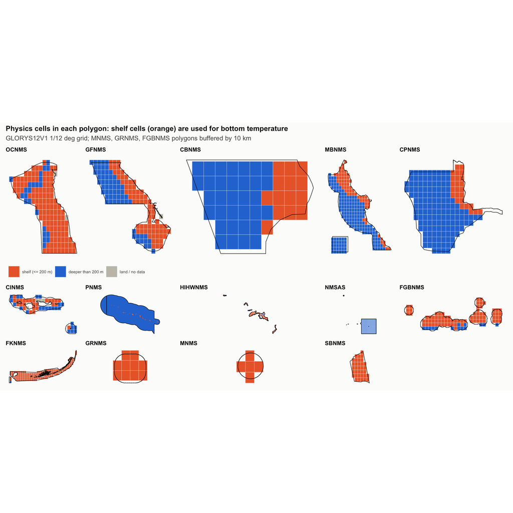

```r
map_one <- function(nms, d, r_res, cols) {
  # one legend for the panel: only the first map keeps it
  leg <- if (nms == NMS_ORD[1]) "bottom" else "none"
  p <- ply_use |> filter(nms == !!nms)
  d <- d |> filter(nms == !!nms)
  if (nms == "PNMS") {
    p <- st_shift_longitude(p)
    d <- d |> mutate(x = if_else(x < 0, x + 360, x))
  }
  ggplot() +
    geom_tile(data = d, aes(x, y, fill = class), width = r_res[1], height = r_res[2],
              color = if (nrow(d) > 2000) NA else "white", linewidth = 0.1) +
    geom_sf(data = p, fill = NA, color = PAL$ink, linewidth = 0.3) +
    scale_fill_manual(values = cols, limits = names(cols), drop = F) +
    labs(title = nms, x = NULL, y = NULL, fill = NULL) +
    theme_chk(8) +
    theme(axis.text = element_blank(), panel.grid.major = element_blank(), legend.position = leg)
}

COL_PHY <- c("shelf (<= 200 m)" = PAL$orange, "deeper than 200 m" = PAL$blue, "land / no data" = PAL$axis)
d_cls_phy$class <- factor(d_cls_phy$class, names(COL_PHY))
p_phy <- map(NMS_ORD, \(n) map_one(n, d_cls_phy, res[[n]]$res_phy, COL_PHY)) |>
  wrap_plots(ncol = 5) +
  plot_annotation(
    title    = "Physics cells in each polygon: shelf cells (orange) are used for bottom temperature",
    subtitle = "GLORYS12V1 1/12 deg grid; MNMS, GRNMS, FGBNMS polygons buffered by 10 km",
    theme    = theme_chk())
save_fig(p_phy, "cells_physics.png", width = 11, height = 11)
```

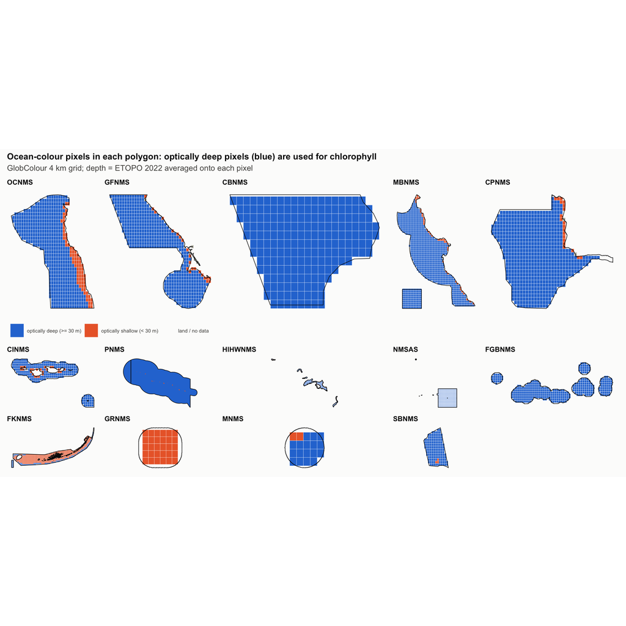

```r
COL_OC <- c(
  "optically deep (>= 30 m)" = PAL$blue, "optically shallow (< 30 m)" = PAL$orange, "land / no data" = PAL$axis)
d_cls_oc$class <- factor(d_cls_oc$class, names(COL_OC))
p_oc <- map(NMS_ORD, \(n) map_one(n, d_cls_oc, res[[n]]$res_oc, COL_OC)) |>
  wrap_plots(ncol = 5) +
  plot_annotation(
    title    = "Ocean-colour pixels in each polygon: optically deep pixels (blue) are used for chlorophyll",
    subtitle = "GlobColour 4 km grid; depth = ETOPO 2022 averaged onto each pixel",
    theme    = theme_chk())
save_fig(p_oc, "cells_oceancolour.png", width = 11, height = 11)
```

## Masked versus old definitions

Anomalies are departures from the 2003-2012 monthly climatology; chlorophyll is compared on log10. `change` = mean 2016-2025 minus mean 2003-2012 (degC for `sbt`, log10 mg m-3 for `chl`). `mean_diff` = masked minus old, in raw units.

```r
anom <- function(d) {
  d |>
    mutate(m = as.integer(format(date, "%m"))) |>
    group_by(m) |>
    mutate(anom = value - mean(value[date >= as.Date("2003-01-01") & date <= as.Date("2012-12-01")])) |>
    ungroup()
}
change <- function(date, value) {
  mean(value[date >= as.Date("2016-01-01") & date <= as.Date("2025-12-01")]) -
    mean(value[date >= as.Date("2003-01-01") & date <= as.Date("2012-12-01")])
}

d_compare <- map(
  list(c("sbt", "sbt_all", "identity", "degC"), c("chl", "chl_all", "log10", "log10 mg m-3")), \(pr) {
    tr <- match.fun(pr[3])
    d_state |>
      filter(var %in% pr[1:2]) |>
      select(nms, date, var, value) |>
      pivot_wider(names_from = var, values_from = value) |>
      rename(masked = !!pr[1], old = !!pr[2]) |>
      filter(!is.na(masked), !is.na(old)) |>
      group_by(nms) |>
      group_modify(\(d, k) {
        a_m <- anom(d |> transmute(date, value = tr(masked)))$anom
        a_o <- anom(d |> transmute(date, value = tr(old)))$anom
        tibble(
          cor_anom      = cor(a_m, a_o),
          mean_diff     = mean(d$masked - d$old),
          change_masked = change(d$date, tr(d$masked)),
          change_old    = change(d$date, tr(d$old)))
      }) |>
      ungroup() |>
      mutate(pair = glue("{pr[1]} vs {pr[2]}"), units_change = pr[4], .after = nms)
  }) |>
  bind_rows() |>
  right_join(expand_grid(nms = NMS_ORD, pair = c("sbt vs sbt_all", "chl vs chl_all")), by = c("nms", "pair")) |>
  mutate(nms = factor(nms, NMS_ORD)) |>
  arrange(pair != "sbt vs sbt_all", nms) |>
  mutate(
    nms          = as.character(nms),
    pair         = as.character(pair),
    units_change = coalesce(units_change, if_else(pair == "sbt vs sbt_all", "degC", "log10 mg m-3")))

d_compare |>
  mutate(across(where(is.numeric), \(x) round(x, 3))) |>
  kable(caption = "Masked versus old definitions (NA: no shelf cells, so no masked sbt).")
```

Masked versus old definitions (NA: no shelf cells, so no masked sbt).

| nms | pair | units_change | cor_anom | mean_diff | change_masked | change_old |
| --- | --- | --- | --- | --- | --- | --- |
| OCNMS | sbt vs sbt_all | degC | 0.998 | 0.307 | 0.460 | 0.405 |
| GFNMS | sbt vs sbt_all | degC | 0.995 | 2.746 | 0.598 | 0.359 |
| CBNMS | sbt vs sbt_all | degC | 0.981 | 4.184 | 0.430 | 0.195 |
| MBNMS | sbt vs sbt_all | degC | 0.968 | 4.737 | 0.704 | 0.263 |
| CPNMS | sbt vs sbt_all | degC | 0.802 | 5.908 | 0.862 | 0.190 |
| CINMS | sbt vs sbt_all | degC | 0.973 | 1.723 | 0.296 | 0.260 |
| PNMS | sbt vs sbt_all | degC | 0.658 | 22.106 | 0.325 | 0.027 |
| HIHWNMS | sbt vs sbt_all | degC | 0.982 | 1.570 | 0.273 | 0.162 |
| NMSAS | sbt vs sbt_all | degC | NA | NA | NA | NA |
| FGBNMS | sbt vs sbt_all | degC | 0.962 | -0.162 | 0.436 | 0.390 |
| FKNMS | sbt vs sbt_all | degC | 1.000 | 0.113 | 0.750 | 0.745 |
| GRNMS | sbt vs sbt_all | degC | 1.000 | 0.031 | 0.542 | 0.543 |
| MNMS | sbt vs sbt_all | degC | 0.972 | -0.958 | 1.595 | 1.542 |
| SBNMS | sbt vs sbt_all | degC | 1.000 | 0.000 | 1.156 | 1.156 |
| OCNMS | chl vs chl_all | log10 mg m-3 | 0.963 | -0.904 | -0.031 | -0.036 |
| GFNMS | chl vs chl_all | log10 mg m-3 | 0.944 | -0.802 | -0.045 | -0.057 |
| CBNMS | chl vs chl_all | log10 mg m-3 | 0.968 | -0.234 | -0.034 | -0.040 |
| MBNMS | chl vs chl_all | log10 mg m-3 | 0.963 | -0.746 | -0.065 | -0.086 |
| CPNMS | chl vs chl_all | log10 mg m-3 | 0.950 | -0.231 | -0.059 | -0.063 |
| CINMS | chl vs chl_all | log10 mg m-3 | 0.983 | -0.298 | -0.099 | -0.113 |
| PNMS | chl vs chl_all | log10 mg m-3 | 0.991 | -0.003 | -0.014 | -0.020 |
| HIHWNMS | chl vs chl_all | log10 mg m-3 | 0.957 | -0.012 | 0.030 | 0.041 |
| NMSAS | chl vs chl_all | log10 mg m-3 | 0.999 | 0.000 | 0.027 | 0.028 |
| FGBNMS | chl vs chl_all | log10 mg m-3 | 0.978 | 0.009 | -0.004 | -0.012 |
| FKNMS | chl vs chl_all | log10 mg m-3 | 0.307 | -0.699 | 0.015 | 0.152 |
| GRNMS | chl vs chl_all | log10 mg m-3 | 0.997 | 0.008 | 0.003 | 0.004 |
| MNMS | chl vs chl_all | log10 mg m-3 | 0.992 | -0.084 | -0.109 | -0.109 |
| SBNMS | chl vs chl_all | log10 mg m-3 | 0.998 | -0.063 | -0.020 | -0.022 |

## Write

```r
# reproduce data/copernicus.csv with the old rule before writing anything ----
# sst is compared only where the polygon is unchanged (not buffered, not the designated chnms)
NMS_CHG <- c(NMS_BUF, if (chnms_inside) "CPNMS")
d_old <- read_csv(copernicus_csv) |>
  filter(
    nms %in% NMS_CM, stat == "mean",
    str_detect(dataset, "_my_"),                          # drop myint duplicates
    str_remove(var, "_depth=.*$") %in% c("bottomT", "CHL", "thetao")) |>
  transmute(
    nms, date = as.Date(time),
    var = recode(str_remove(var, "_depth=.*$"), bottomT = "sbt_all", CHL = "chl_all", thetao = "sst"),
    value_old = value) |>
  distinct(nms, date, var, .keep_all = T)

d_agree <- d_state |>
  inner_join(d_old, by = c("nms", "date", "var")) |>
  filter(var != "sst" | !nms %in% NMS_CHG) |>
  group_by(var, nms) |>
  summarize(n = n(), max_abs_diff = max(abs(value - value_old)), .groups = "drop")

d_agree |>
  pivot_wider(id_cols = nms, names_from = var, values_from = max_abs_diff) |>
  mutate(nms = factor(nms, NMS_ORD)) |>
  arrange(nms) |>
  kable(digits = 9, caption = "Maximum absolute difference from data/copernicus.csv (old rule).")
```

Maximum absolute difference from data/copernicus.csv (old rule).

| nms | chl_all | sbt_all | sst |
| --- | --- | --- | --- |
| OCNMS | 0 | 0 | 0 |
| GFNMS | 0 | 0 | 0 |
| CBNMS | 0 | 0 | 0 |
| MBNMS | 0 | 0 | 0 |
| CPNMS | 0 | 0 | NA |
| CINMS | 0 | 0 | 0 |
| HIHWNMS | 0 | 0 | 0 |
| NMSAS | 0 | 0 | 0 |
| FGBNMS | 0 | 0 | NA |
| FKNMS | 0 | 0 | 0 |
| GRNMS | 0 | 0 | NA |
| MNMS | 0 | 0 | NA |
| SBNMS | 0 | 0 | 0 |

```r
stopifnot(
  all(d_agree$max_abs_diff < TOL),
  setequal(d_agree$nms[d_agree$var == "sbt_all"], NMS_CM),
  setequal(d_agree$nms[d_agree$var == "chl_all"], NMS_CM),
  setequal(d_agree$nms[d_agree$var == "sst"], setdiff(NMS_CM, NMS_CHG)))
```

```r
write_csv(d_state,   monthly_csv, na = "NA")
write_csv(d_cells,   cells_csv,   na = "NA")
write_csv(d_compare, compare_csv, na = "NA")
```

## Checks

```r
chk_m <- read_csv(monthly_csv, col_types = cols(date = col_date(), n_cells = col_integer(), .default = col_guess()))
chk_c <- read_csv(cells_csv)
chk_k <- read_csv(compare_csv)

rng <- chk_m |>
  group_by(var) |>
  summarize(
    first = min(date), last = max(date), n_months = n_distinct(date),
    n_nms = n_distinct(nms), n_rows = n(), n_na = sum(is.na(value)))
kable(rng, caption = "state_monthly.csv by variable")
```

state_monthly.csv by variable

| var | first | last | n_months | n_nms | n_rows | n_na |
| --- | --- | --- | --- | --- | --- | --- |
| chl | 1997-09-01 | 2026-03-01 | 343 | 14 | 4802 | 0 |
| chl_all | 1997-09-01 | 2026-03-01 | 343 | 14 | 4802 | 0 |
| mld | 1993-01-01 | 2026-02-01 | 398 | 14 | 5572 | 0 |
| pp | 1997-09-01 | 2026-03-01 | 343 | 14 | 4802 | 0 |
| precip | 1998-01-01 | 2025-09-01 | 333 | 14 | 4662 | 0 |
| sbt | 1993-01-01 | 2026-02-01 | 398 | 14 | 5572 | 398 |
| sbt_all | 1993-01-01 | 2026-02-01 | 398 | 14 | 5572 | 0 |
| sss | 1993-01-01 | 2026-02-01 | 398 | 14 | 5572 | 0 |
| sst | 1993-01-01 | 2026-02-01 | 398 | 14 | 5572 | 0 |

```r
n_na_sbt <- sum(tbl_n$shelf < SHELF_MIN)
stopifnot(
  identical(names(chk_m), c("nms", "date", "var", "value", "n_cells", "rule")),
  setequal(unique(chk_m$var), VARS_OUT),
  setequal(unique(chk_m$nms), NMS_ORD),
  length(NMS_ORD) == 14,
  !anyDuplicated(chk_m[, c("nms", "date", "var")]),
  all(format(chk_m$date, "%d") == "01"),
  # one row per sanctuary x month for every var
  all(rng$n_rows == rng$n_months * length(NMS_ORD)),
  rng$first[rng$var == "sst"]    == as.Date("1993-01-01"),
  rng$first[rng$var == "chl"]    == as.Date("1997-09-01"),
  rng$first[rng$var == "precip"] == as.Date("1998-01-01"),
  rng$last[rng$var == "precip"]  == as.Date("2025-09-01"),
  # NA only where sbt has no shelf cells
  sum(is.na(chk_m$value)) == n_na_sbt * rng$n_months[rng$var == "sbt"],
  all(is.na(chk_m$n_cells[chk_m$var == "precip" & chk_m$nms %in% NMS_CM])),
  all(chk_m$n_cells[chk_m$var == "precip" & chk_m$nms == "PNMS"] >= 1),
  all(chk_m$n_cells[chk_m$var != "precip" & !is.na(chk_m$value)] >= 1),
  identical(names(chk_c), c(
    "nms", "var", "n_cells_median", "n_cells_min", "n_cells_max", "rule",
    "depth_min_m", "depth_max_m", "area_km2")),
  nrow(chk_c) == length(NMS_ORD) * 8,
  identical(names(chk_k), c(
    "nms", "pair", "units_change", "cor_anom", "mean_diff", "change_masked", "change_old")),
  nrow(chk_k) == length(NMS_ORD) * 2)
```

All checks passed: 46928 rows in `state_monthly.csv` (14 sanctuaries), 112 in `state_cells.csv`, 28 in `state_compare.csv`.